# Module 12: Inference

Author

Affiliation

Adam Spiegler

University of Colorado Denver

## Additional Reading

- [Chapter 6 Linear Model Inference and Prediction](https://jfrench.github.io/LinearRegression/inference.html#overview-of-inference-and-prediction) from *A Progressive Introduction to Linear Models*
- Chapter 6 of *Linear Regression Models: Applications in R* ([link to library ebook](https://go.exlibris.link/Q7wgCRrz))
- Chapter 6 of *Applied Linear Regression* ([link to library ebook](https://go.exlibris.link/69jsQwWW))

# Loading Required Packages and Data

```r
library(tidyverse)
library(faraway)  # access gala data frame
library(ellipse)
```

**Note**

We have not used the `ellipse` package yet this semester. If you have not installed this package, be sure to run the command `install.packages("ellipse")` from the console below and re-run the code cell above.

```r
# loading Galapagos data
data(gala)
head(gala)
```

```
             Species Endemics  Area Elevation Nearest Scruz Adjacent
Baltra            58       23 25.09       346     0.6   0.6     1.84
Bartolome         31       21  1.24       109     0.6  26.3   572.33
Caldwell           3        3  0.21       114     2.8  58.7     0.78
Champion          25        9  0.10        46     1.9  47.4     0.18
Coamano            2        1  0.05        77     1.9   1.9   903.82
Daphne.Major      18       11  0.34       119     8.0   8.0     1.84
```

```r
summary(gala)
```

```
    Species          Endemics          Area             Elevation
 Min.   :  2.00   Min.   : 0.00   Min.   :   0.0100   Min.   :  25.00
 1st Qu.: 13.00   1st Qu.: 7.25   1st Qu.:   0.2575   1st Qu.:  97.75
 Median : 42.00   Median :18.00   Median :   2.5900   Median : 192.00
 Mean   : 85.23   Mean   :26.10   Mean   : 261.7087   Mean   : 368.03
 3rd Qu.: 96.00   3rd Qu.:32.25   3rd Qu.:  59.2375   3rd Qu.: 435.25
 Max.   :444.00   Max.   :95.00   Max.   :4669.3200   Max.   :1707.00
    Nearest          Scruz           Adjacent
 Min.   : 0.20   Min.   :  0.00   Min.   :   0.03
 1st Qu.: 0.80   1st Qu.: 11.03   1st Qu.:   0.52
 Median : 3.05   Median : 46.65   Median :   2.59
 Mean   :10.06   Mean   : 56.98   Mean   : 261.10
 3rd Qu.:10.03   3rd Qu.: 81.08   3rd Qu.:  59.24
 Max.   :47.40   Max.   :290.20   Max.   :4669.32
```

- `Species`: The number of plant species found on the island.
- `Area`: The area of the island ($\mbox{km}^2$).
- `Elevation`: The highest elevation of the island (m).
- `Nearest`: The distance from the nearest island (km).
- `Scruz`: The distance from Santa Cruz Island (km).
- `Adjacent`: The area of the adjacent island ($\mbox{km}^2$).

# Hypothesis Testing for a Simple Linear Regression

## Question 1

Write out a formula for the fitted model based on code and output below.

```r
lmod_area <- lm(Species ~ Area, data = gala)
summary(lmod_area)
```

```
Call:
lm(formula = Species ~ Area, data = gala)

Residuals:
    Min      1Q  Median      3Q     Max
-99.495 -53.431 -29.045   3.423 306.137

Coefficients:
            Estimate Std. Error t value Pr(>|t|)
(Intercept) 63.78286   17.52442   3.640 0.001094 **
Area         0.08196    0.01971   4.158 0.000275 ***
---
Signif. codes:  0 '***' 0.001 '**' 0.01 '*' 0.05 '.' 0.1 ' ' 1

Residual standard error: 91.73 on 28 degrees of freedom
Multiple R-squared:  0.3817,    Adjusted R-squared:  0.3596
F-statistic: 17.29 on 1 and 28 DF,  p-value: 0.0002748
```

### Solution to Question 1

## Setting Up The Hypotheses

## Question 2

What do you think would be suitable hypothesis to test whether the predictor `Area` should be included?

### Solution to Question 2

## Calculating the Test Statistic

If the null hypotheses is true, how likely would we be to obtain the observed sample data?

$$t = \frac{\text{observed} - \text{null}}{\text{SE}} = \frac{\widehat{\beta}_1 - 0}{\text{SE}(\widehat{\beta}_1)}.$$

Recall the OLS estimate for $\hat{\beta}_1$ is

$$\hat{\beta}_1 = \frac{\sum (x_i - \bar{x})(y - \bar{y})}{\sum (x_i - \bar{x})^2}.$$

$$\text{SE}(\widehat{\beta}_1) = \sqrt{ \frac{\sum (\hat{y}_i - y_i)^2 / (n-2)}{\sum (x_i - \bar{x})^2 }}.$$

- $\frac{\sum (\hat{y}_i - y_i)^2$ is the RSS of the model with `Area` as the only predictor.
- $n-2$ denotes the degrees of freedom with $2$ being the number of regression coefficients.
- $\sum (x_i - \bar{x})^2$ is the total sum of the squared deviance in the predictor.

## Question 3

Approximate the standard error for $\widehat{\beta}_1$. Then use this result to compute the test statistic and p-value corresponding to this test.

### Solution to Question 3

# Hypothesis Tests with Multiple Linear Regression

## Question 4

Write out a formula for the fitted model based on code and output below.

```r
lmod <- lm(Species ~ Area + Elevation + Nearest +
            Scruz + Adjacent, data = gala)
summary(lmod)
```

```
Call:
lm(formula = Species ~ Area + Elevation + Nearest + Scruz + Adjacent,
    data = gala)

Residuals:
     Min       1Q   Median       3Q      Max
-111.679  -34.898   -7.862   33.460  182.584

Coefficients:
             Estimate Std. Error t value Pr(>|t|)
(Intercept)  7.068221  19.154198   0.369 0.715351
Area        -0.023938   0.022422  -1.068 0.296318
Elevation    0.319465   0.053663   5.953 3.82e-06 ***
Nearest      0.009144   1.054136   0.009 0.993151
Scruz       -0.240524   0.215402  -1.117 0.275208
Adjacent    -0.074805   0.017700  -4.226 0.000297 ***
---
Signif. codes:  0 '***' 0.001 '**' 0.01 '*' 0.05 '.' 0.1 ' ' 1

Residual standard error: 60.98 on 24 degrees of freedom
Multiple R-squared:  0.7658,    Adjusted R-squared:  0.7171
F-statistic:  15.7 on 5 and 24 DF,  p-value: 6.838e-07
```

### Solution to Question 4

$$\widehat{\mbox{Species}} = ?? + ?? \mbox{Area} + ?? \mbox{Elevation} + ?? \mbox{Nearest} + ?? \mbox{Scruz} + ?? \mbox{Adjacent}$$

## Question 5

Which regressor has the strongest association with the number species on the island? Explain how you determined your answer.

### Solution to Question 5

# Setting Up The Hypotheses

How can we decide whether all or some of the regressor variables should be included in our model?

- Let $\Omega$ denote the proposed **complete or full model**.
- Let $\omega$ denote a **simpler model** that uses a subset of all regressors.

## Question 6

What do you think would be suitable hypothesis to test whether $\Omega$ is a better model than $\omega$?

### Solution to Question 6

# Measuring Significance

- If the models have a similar fit, then we prefer $\omega$ since it is simpler.
- If the model $\Omega$ is a much better model than $\omega$, then we prefer $\Omega$.
- If $\mbox{RSS}_{\omega} - \mbox{RSS}_{\Omega}$ is large, then $\Omega$ has a superior fit.
- How large of a difference is large enough?

## An Initial Test Statistic

$$\mbox{test stat} = \frac{\mbox{fit of observed model} - \mbox{fit of null model}}{\mbox{variability due to sampling}} = \frac{\mbox{RSS}_{\omega} - \mbox{RSS}_{\Omega}}{RSS_{\Omega}}.$$

## The $F$-Statistic

The **$F$-statistic** compare the variance explained by the model to the variance not explained (the residuals). The $F$-statistic is used to test whether the **overall regression model is statistically significant**, not just individual predictors. Recall the following measurements related to a regression model:

- $\mbox{RSS} = \sum (Y_i - \widehat{Y}_i)^2$ is the **Residual Sum of Squares (RSS)**.
- RSS measures the variability in our response that **is NOT explained by our model**.

Suppose that model $\Omega$ has $p$ estimated regression coefficients and model $\omega$ has $q$ estimated regression coefficients. In other words, model $\Omega$ considers adding $p-q$ predictors to simpler model $\omega$.

- $\mbox{RSS}_{\omega} - \mbox{RSS}_{\Omega}$ is the additional variance in the response that was not explained by $\omega$ (simpler model) but is explained by $\Omega$ (complete model).
- Dividing by $df_{\omega}-df_{\Omega} = (n - q) - (n - p) = p-q$ averages the change in the RSS per additional regressor added.
- The denominator $RSS_{\Omega}/df_{\Omega} = RSS_{\Omega}/(n-p)$ is the mean (per regressor) of the remaining unexplained variance.

$$F = \frac{(\mbox{RSS}_{\omega} - \mbox{RSS}_{\Omega})/(df_{\omega}-df_{\Omega})}{RSS_{\Omega}/df_{\Omega}} = \frac{(\mbox{RSS}_{\omega} - \mbox{RSS}_{\Omega})/(df_{\omega}-df_{\Omega})}{\hat{\sigma}_{\Omega}^2} \sim F_{p-q,n-p} .$$

The $F$-statistic is the ratio that compares the variance in the response explained by the complete model $\Omega$ to the variance not explained by the complete model. A **large $F$-statistic** indicates the **model’s predictors are jointly useful** in explaining the response variable.

**Note**

We divide each $RSS$ by its degrees of freedom to calculate an **unbiased** estimate of the mean variance similar to how we divide by $n-1$ when finding an unbiased estimate for the standard deviation. This prevents underestimation.

# Compute the p-value

If we assume $H_0$ is true, the $F$-statistic follows an $F$-distribution with degrees of freedom $p-q$ and $n-p$.

## Visualizing the F-dist

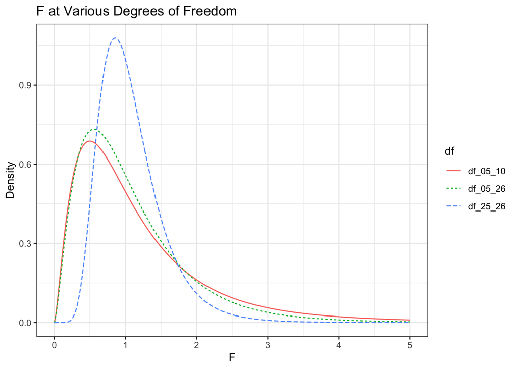

- If $\mbox{df}_1 = p-1$ is constant and we increase $\mbox{df}_2 = \mbox{df}_{\Omega} = n-p$, the center hump is centered around the same $F$ value, but there is more area in the hump and less in the right tail.
- If $\mbox{df}_2 = n-p$ is constant and we increase $\mbox{df}_1 = \mbox{df}_{\Omega} = p-1$, the center hump shifts to the right and there is more area concentrated near the peak and less in the tail to the right.

Let `f_star` denote the $F$-statistic associated to our regression models, then we have

```
df1 <- p-q  # number of added predictors
df2 <- n-p  # degrees of freedom of complete model
1 - pf(f_star, df1, df2)  # area in upper tail
```

**Note**

The $F$-statistic and $p$-value are computed when constructing a linear model with the `lm()` function in R. Both are provided in the `summary()` of an `lm` object. Thus, we typically just run the `lm()` command in R to obtain these values.

# Make A Conclusion

Let $\alpha$ denote the **significance level** of the test which is chosen by the researcher. By default, we use $\alpha = 0.05$.

- If $p$-value $\leq \alpha$, the test is statistically significant.
  - We can reject $H_0$ and have signicant evidence that $H_a$ is true.
  - The full model $\Omega$ is better than the simpler model $\omega$.
- If $p$-value $> \alpha$, the test is NOT statistically significant.
  - We fail to reject (or accept $H_0$) and cannot say anything about the claim in $H_a$.
  - The test is inconclusive.
  - We cannot be sure whether or not $\omega$ or $\Omega$ is a better model.
  - In which case, we typically use the simpler model $\omega$.

# Example Are Any Predictors Useful?

To see if any of the predictors in a possible model are useful, we compare the full model $\Omega$ given by $\mathbf{y} = \mathbf{X} \boldsymbol{\beta} + \boldsymbol{\epsilon}$ to the null model $\omega$ which is the constant mean model $\mathbf{y} = \mu_Y + \boldsymbol{\epsilon}$ which we estimate with $\hat{y} = \bar{y}$.

## Question 7: Set up the hypotheses

Set up the hypotheses to see whether or not the full model in Question 4 is better model than the null model.

### Solution to Question 7

## Question 8: Measure Significance

Using the model from Question 4, identify the $F$-statistic and $p$-value for this test.

*Bonus: Try to calculate the $F$-statistic using the formula above to confirm.*

### Solution to Question 8:

## Question 9: Make a conclusion (if possible)

Based on the previous results, state a formal conclusion of this test (if there is one). Then summary the conclusion in the context of this example.

### Solution to Question 9

# Analysis of Variation (ANOVA) Table

The information above is often presented in an **analysis of variation (ANOVA) table** which is convenient for summarizing and organizing the various ingredients in the $F$-statistic. Below is a typical ANOVA table when comparing a full model $\Omega$ with $p$ regressors to a simpler model $\omega$ with $q$ regressors.

[output not shown]

- **Regression**: The variance that is explained by the additional variable(s) of interest in $\Omega$ that are not included in $\omega$.
- **Residuals**: The variance that is not explained by the complete model $\Omega$. This is the $\text{RSS}_{\Omega}$.
- **Total**: The variation that is unexplained by the simpler model $\omega$.

There is the `anova()` function in R can be used compute components of the $F$-statistic corresponding to a test for a regression model. The command `anova(simple_lmod, complete_lmod)` gives an ANOVA table with the following organization.

| Source | Res.Df | RSS | Df | Sum of Sq | F | Pr( > F) |
| --- | --- | --- | --- | --- | --- | --- |
| 1 (simple model, $\omega$) | $n-q$ | $\text{RSS}_{\omega}$ |  |  |  |  |
| 2 (complete model, $\Omega$) | $n-p$ | $\text{RSS}_{\Omega}$ | $p-q$ | $\text{RSS}_{\omega} - \text{RSS}_{\Omega}$ | $F$-stat | $p$-value |

## Question 10

In questions 7-9 we performed a hypothesis test to compare the full model (include all 5 predictors stored in `lmod`) to the null model (intercept only stored in `nullmod`). Play around with the code below to fill in the ANOVA table provided below.

```r
nullmod <- lm(Species ~ 1, data = gala)
```

```r
deviance(lmod)
```

```
[1] 89231.37
```

```r
deviance(nullmod)
```

```
[1] 381081.4
```

```r
deviance(nullmod) - deviance(lmod)
```

```
[1] 291850
```

```r
n <- nrow(gala)  # number of observations
p <- 6  # 6 regressors in full model
q <- 1  # 1 regressor in null model
```

### Solution to Question 10

| Source | Deg. of Freedom | Sum of Squares | Mean Square | F |
| --- | --- | --- | --- | --- |
| Regression | ?? | ?? | ?? | ?? |
| Residuals | ?? | ?? | ?? |  |
| Total | ?? | ?? |  |  |

## Question 11

Run the code cell below to generate an ANOVA table in R and compare with the table you created in the previous question. Then run the second code cell to compare with the summary output of the complete model, `lmod`.

```r
anova(nullmod, lmod)
```

```
Analysis of Variance Table

Model 1: Species ~ 1
Model 2: Species ~ Area + Elevation + Nearest + Scruz + Adjacent
  Res.Df    RSS Df Sum of Sq      F    Pr(>F)
1     29 381081
2     24  89231  5    291850 15.699 6.838e-07 ***
---
Signif. codes:  0 '***' 0.001 '**' 0.01 '*' 0.05 '.' 0.1 ' ' 1
```

```r
summary(lmod)
```

```
Call:
lm(formula = Species ~ Area + Elevation + Nearest + Scruz + Adjacent,
    data = gala)

Residuals:
     Min       1Q   Median       3Q      Max
-111.679  -34.898   -7.862   33.460  182.584

Coefficients:
             Estimate Std. Error t value Pr(>|t|)
(Intercept)  7.068221  19.154198   0.369 0.715351
Area        -0.023938   0.022422  -1.068 0.296318
Elevation    0.319465   0.053663   5.953 3.82e-06 ***
Nearest      0.009144   1.054136   0.009 0.993151
Scruz       -0.240524   0.215402  -1.117 0.275208
Adjacent    -0.074805   0.017700  -4.226 0.000297 ***
---
Signif. codes:  0 '***' 0.001 '**' 0.01 '*' 0.05 '.' 0.1 ' ' 1

Residual standard error: 60.98 on 24 degrees of freedom
Multiple R-squared:  0.7658,    Adjusted R-squared:  0.7171
F-statistic:  15.7 on 5 and 24 DF,  p-value: 6.838e-07
```

### Solution to Question 11

# Testing a Single Regressor

To test whether a single regressor (regressor j) can be dropped from the model, we choose between $H_0:\beta_j = 0$ and $H_a: \beta_j \ne 0$.

We have two options in this case:

- Use the previous approach, letting the reduced model be the one without that regressor.
- Use a $t$-statistic approach.

## Question 12

Repeat the previous process to test whether the regressor `Area` is significant (assuming all others are in the model).

- State the hypotheses.
- Compute the $F$-statistic and $p$-value.
- State the conclusion in this context.

### Solution to Question 12

## Using a t-statistic

An alternative approach is to use a $t$-statistic for testing the hypotheses:

$$t_i = \frac{\widehat{\beta}_i-0}{\mbox{se}(\widehat{\beta}_i)}= \frac{\widehat{\beta}_i}{\mbox{se}(\widehat{\beta}_i)}$$
using a $t$-distribution with $\mbox{df}_{\Omega}=n-p$ degrees of freedom.

```r
# calculation of t-stat
beta.area <- summary(lmod)$coeff[2,1]
se.area <- summary(lmod)$coeff[2,2]
(t <- beta.area/se.area)
```

```
[1] -1.067611
```

```r
# verifying p-value
2*pt(t, df.residual(lmod))
```

```
[1] 0.296318
```

```r
# matching F-stat
t^2
```

```
[1] 1.139792
```

## Question 13

What is the difference between the test being run in the code below and the previous test? Does the test below lead to the same conclusion?

```r
# compare results to test of beta_Area = 0 when no other predictors in model
summary(lm(Species ~ Area, gala))
```

```
Call:
lm(formula = Species ~ Area, data = gala)

Residuals:
    Min      1Q  Median      3Q     Max
-99.495 -53.431 -29.045   3.423 306.137

Coefficients:
            Estimate Std. Error t value Pr(>|t|)
(Intercept) 63.78286   17.52442   3.640 0.001094 **
Area         0.08196    0.01971   4.158 0.000275 ***
---
Signif. codes:  0 '***' 0.001 '**' 0.01 '*' 0.05 '.' 0.1 ' ' 1

Residual standard error: 91.73 on 28 degrees of freedom
Multiple R-squared:  0.3817,    Adjusted R-squared:  0.3596
F-statistic: 17.29 on 1 and 28 DF,  p-value: 0.0002748
```

### Solution to Question 13

# Testing a Pair of Regressors

## Question 14

Test whether the `Area` and `Adjacent` regressor variables should be simultaneously dropped from the model that already includes `Elevation`, `Nearest`, and `Scruz` in the model. Make sure to specify the regressors that are the model when stating H<sub>0</sub> and H<sub>a</sub>.

- State the hypotheses.
- Compute the $F$-statistic and $p$-value.
- State the conclusion in this context.

### Solution to Question 14

# Confidence Intervals

An alternative way of expressing the uncertainty in an estimate for a population parameter is through **confidence intervals (CIs)**. A confidence interval interval is an interval estimate with an associated confidence level corresponding to the success rate.

## Example: Confidence Interval for Mean

Suppose we want to find a 95% confidence interval to estimate the average weight (in pounds) of all Komodo dragons. We have a sample of $n=8$ Komodo dragons whose sample mean weight is $\bar{x} = 155.5$ pounds with a sample standard deviation of $s = 22.55153$ pounds.

```r
dragon_wt <- c(145, 178, 142, 139, 160, 190, 168, 122)  # load sample of weights
(wt_mean <- mean(dragon_wt))
```

```
[1] 155.5
```

```r
(wt_sd <- sd(dragon_wt))
```

```
[1] 22.55153
```

```r
wt_n <- length(dragon_wt)
```

- A reasonable **point estimate** is $\mu \approx \bar{x} = 155.5$.
- Another person with a slightly different sample we have a slightly different estimate.
- Let’s build in a margin of error into our estimate to account for the variability due to the randomness of sampling.

A corresponding $t$-distribution confidence interval is given by

$${\large \overline{X} - {\color{red}{t_{n-1}^{\alpha/2}}} \cdot \frac{s}{\sqrt{n}} < \mu < \overline{X} + {\color{red}{t_{n-1}^{\alpha/2}}} \cdot \frac{s}{\sqrt{n}}},$$

where the area under the $t$-distribution with $n-1$ degrees of freedom between ${\color{red}{\pm t_{\alpha/2}}}$ is equal to the confidence level.

```r
se_wt <- wt_sd / sqrt(wt_n)  # estimate for standard error of x-bar
```

```r
df_wt <- 8 - 1  # n - 1 degrees of freedom
(t_star <- qt(0.025, df_wt))  # exclude lower 2.5%
```

```
[1] -2.364624
```

```r
(moe_wt <- abs(t_star) * se_wt)
```

```
[1] 18.85355
```

```r
(lower_wt <- wt_mean - moe_wt)
```

```
[1] 136.6465
```

```r
(upper_wt <- wt_mean + moe_wt)
```

```
[1] 174.3535
```

A 95% confidence interval for the mean weight of all Komodo dragons is therefore $155.5 \pm 18.85$ pounds or

$$136.65 \text{ pounds} < \mu < 174.35 \text{ pounds}.$$

### Interpreting a 95% Confidence Interval

- The interval is used to estimate a population parameter. In this case, the mean of ALL adult Komodo dragons.
- We should indicate the odds of success.
- We should attach the uncertainty to the interval we constructed (which is random).
- We should NOT attach the uncertainty to the parameter we are estimating (which is not random, it is fixed).

## Confidence Intervals for Regression Coefficients

To construct a confidence interval for a regression coefficient with confidence level $CL = 1 - \alpha$, we have:

$$\widehat{\beta}_j \ \pm \ {\color{red}{t_{n-p}^{\alpha/2}}} \ \ \mbox{SE}(\widehat{\beta}_j).$$

The resulting interval has a given odds of success (confidence level) for containing the actual value of the regression coefficient.

## Question 15

Use the output from the code below to constructing a 95% confidence interval for the `Area` slope coefficient $\beta_{\rm Area}$ (assuming all 4 other predictors in the model). Interpret the practical meaning of the interval.

```r
lmod <- lm(Species ~ Area + Elevation + Nearest + Scruz + Adjacent, data = gala)
summary(lmod)
```

```
Call:
lm(formula = Species ~ Area + Elevation + Nearest + Scruz + Adjacent,
    data = gala)

Residuals:
     Min       1Q   Median       3Q      Max
-111.679  -34.898   -7.862   33.460  182.584

Coefficients:
             Estimate Std. Error t value Pr(>|t|)
(Intercept)  7.068221  19.154198   0.369 0.715351
Area        -0.023938   0.022422  -1.068 0.296318
Elevation    0.319465   0.053663   5.953 3.82e-06 ***
Nearest      0.009144   1.054136   0.009 0.993151
Scruz       -0.240524   0.215402  -1.117 0.275208
Adjacent    -0.074805   0.017700  -4.226 0.000297 ***
---
Signif. codes:  0 '***' 0.001 '**' 0.01 '*' 0.05 '.' 0.1 ' ' 1

Residual standard error: 60.98 on 24 degrees of freedom
Multiple R-squared:  0.7658,    Adjusted R-squared:  0.7171
F-statistic:  15.7 on 5 and 24 DF,  p-value: 6.838e-07
```

### Solution to Question 15

## Question 16

Use the summary output from the code above to similarly construct a 95% confidence interval for the `Elevation` slope coefficient (assuming all 4 other predictors in the model). Interpret the practical meaning of the interval.

### Solution to Question 16

## Finding Confidence Intervals for All Regressors

```r
confint(lmod)
```

```
                  2.5 %      97.5 %
(Intercept) -32.4641006 46.60054205
Area         -0.0702158  0.02233912
Elevation     0.2087102  0.43021935
Nearest      -2.1664857  2.18477363
Scruz        -0.6850926  0.20404416
Adjacent     -0.1113362 -0.03827344
```

# Confidence Regions

When analyzing more than one coefficient at a time, we can use confidence intervals, or we can construct **confidence regions**:

- A confidence region is the same thing as a CI, except that it may have more than one dimension.
- A confidence region provides us with a region of plausible values of our target parameter(s).

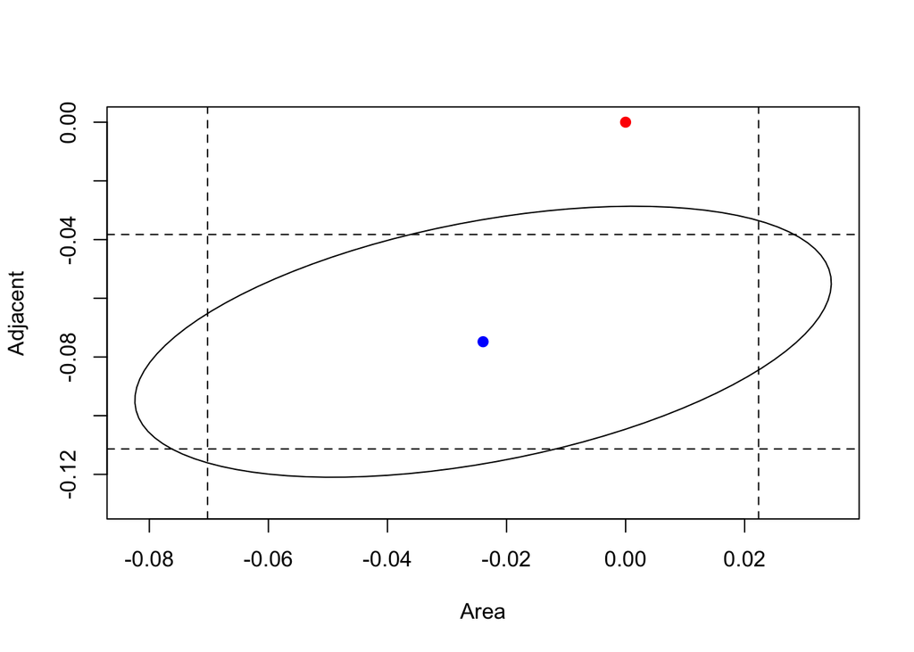

```r
#library(ellipse) # required package to draw confidence region

# construct 95% joint confidence intervals for beta_area and beta_adjacent.
plot(ellipse(lmod, c(2, 6)), type="l", ylim = c(-0.13,0))

# Plot the origin and the center point
points(c(0,coef(lmod)[2]),c(0, coef(lmod)[6]), col = c("red", "blue"), pch = c(19,19))

# add vertical and horizontal lines for individual confidence intervals
abline(v = confint(lmod)[2,], lty = 2) # plots vertical lines
abline(h = confint(lmod)[6,], lty = 2) # plots horizontal lines
```

## Question 17

Based on the confidence region above, is it plausible that $\beta_{\rm Area} = \beta_{\rm Adjacent}=0$? Why or why not?

### Solution to Question 17

## Question 18

Based on the confidence region above, is it plausible that $\beta_{\rm Area}= -0.06$ and $\beta_{\rm Adjacent}=-0.045$? Why or why not?

### Solution to Question 18

## Reading Confidence Region Plots

- **Any point that lies within** the $100(1- \alpha)\%$ confidence region for $\beta_i,\beta_j, \ldots, \beta_k$ represents values of $c_i,c_j, \ldots ,c_k$ for which the associated **null hypothesis would not be rejected at significance level $\alpha$**.
- **Any point outside of the confidence region** represents values of $c_i, c_j, \ldots ,c_k$ for which the associated **null hypothesis would be rejected**.
- Both the horizontal width and vertical width of the joint confidence region is wider than the widths of the individual confidence intervals.
- The overall area of the joint region is smaller than the area of the intersection between the two individual confidence regions.
  - This is because the estimated regression parameters are positively correlated.
- If the lines of the individual confidence regions were tangential to the joint region, then the individual CIs would be jointly correct (their confidence level would be at least 95%).
- It is possible to make different conclusions when using individual confidence regions in comparison with the joint confidence regions!
- **The joint confidence regions should be preferred**
- We must be cautious about how we interpret univariate hypothesis tests or confidence intervals because the same conclusions may not be jointly true!

# Bootstrap Confidence Intervals

The $F$ and $t$-based confidence regions and intervals we have described depend on assumptions:

- In linear regression, the errors are assumed to be normal.
- In estimating a population mean, if $n < 30$, the underlying population is assumed to be symmetric.
- In general, **parametric CI’s** assume we know the sampling distribution of the statistic that estimates our target parameter.
- How would we approximate the sampling distribution of a statistic using simulated data if we do not know the true error distribution?

**We can use the bootstrap method to produce a confidence interval for our regression coefficients when error distribution is unknown or non-normal.**

## Bootstrap Process for Komodo Dragon Weights

1. Generate a bootstrap resample (same size as original sample) by sampling with replacement from the original sample `dragon_wt`.

```r
dragon_wt <- c(145, 178, 142, 139, 160, 190, 168, 122)  # observed sample
(boot_dragon <- sample(dragon_wt, size = 8, replace = TRUE)) # bootstrap resample
```

```
[1] 178 178 145 178 145 145 178 139
```

2. Compute the relevant statistic (mean in this case) of the bootstrap resample.

```r
mean(boot_dragon)
```

```
[1] 160.75
```

3. Repeat steps 1-2 many times (10,000 times will suffice)

```r
set.seed(123)
N <- 10000  # set the number of bootstrap samples to be generated
boot_dist <- numeric(N)  # place to store bootstrap statistics
n_wt <- length(dragon_wt)

for (i in 1:N){
  temp_dragon <- sample(dragon_wt, size = n_wt, replace = TRUE)  # generate bootstrap resample
  boot_dist[i] <- mean(temp_dragon)
}
```

4. Choose the the interval containing the middle 95% of the bootstrap resamples as the 95% bootstrap percentile confidence interval.

```r
(dragon_boot_cut <- quantile(boot_dist, probs = c(0.025, 0.975)))
```

```
   2.5%   97.5%
141.125 170.125
```

A 95% bootstrap percentile confidence interval is from $141.125$ to $170.125$ pounds.

## Visualizing Bootstrap Confidence Intervals

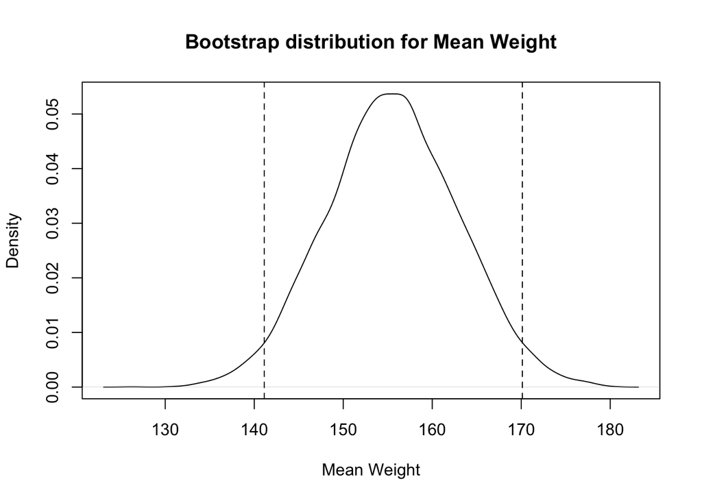

```r
# plot density for bootstrap dist for sample mean weight
plot(density(boot_dist), xlab = "Mean Weight", main = "")
title("Bootstrap distribution for Mean Weight")
abline(v = c(141.125, 170.125), lty = 2)  # plot CI
```

## Bootstrap Process for Regression Coefficients

1. Generate a bootstrap resample $\boldsymbol\epsilon^{\ast}$ by sampling with replacement from $\hat{\epsilon}_1, \hat{\epsilon}_2, \ldots , \hat{\epsilon}_n$.

```r
resids <- residuals(lmod)  # observed residuals
as.vector(resids)
```

```
 [1]  -58.725946   38.273154  -26.330659   14.635734   38.383916  -25.087705
 [7]   -9.919668   19.018992  -20.314202  -28.785943   49.343513   -3.989598
[13]   62.033276  -59.633796   40.497176  -39.403558  -37.694540   -2.037233
[19] -111.679486  -42.475375  -23.075807   -5.553122   73.048122  -40.676318
[25]  182.583587  -23.376486   89.383371   -5.805095  -36.935732   -5.700573
```

```r
n_resids <- length(resids)  # size of each sample
boot_resids <- sample(resids, size = n_resids, replace = TRUE) # bootstrap resample
as.vector(boot_resids)
```

```
 [1]   40.497176   -3.989598  -58.725946  -59.633796  -20.314202  -26.330659
 [7]  -25.087705  -39.403558   -3.989598  182.583587  -42.475375   -5.805095
[13] -111.679486   -5.805095  -20.314202  -23.075807   -3.989598  -20.314202
[19]   62.033276   40.497176  182.583587  -40.676318  -58.725946 -111.679486
[25]  -23.376486  -36.935732   38.383916  -42.475375   -3.989598   73.048122
```

2. Form $\mathbf{y}^{\ast} =X \boldsymbol{\hat{\beta}} + \boldsymbol\epsilon^{\ast}$ for fixed $X$ and using the $\boldsymbol{\hat{\beta}}$ from the fitted model of the original data

```r
new_y <- fitted(lmod) + boot_resids
```

3. Compute $\boldsymbol{\hat{\beta}}^{\ast}$ from $(\mathbf{X},\mathbf{y}^{\ast})$.

```r
boot_model <- lm(new_y ~ Area + Elevation + Nearest + Scruz + Adjacent, data = gala)
coef(boot_model)
```

```
(Intercept)        Area   Elevation     Nearest       Scruz    Adjacent
 2.76478671 -0.03357119  0.32403665 -0.06977631 -0.22838383 -0.07631700
```

```r
coef(lmod)
```

```
 (Intercept)         Area    Elevation      Nearest        Scruz     Adjacent
 7.068220709 -0.023938338  0.319464761  0.009143961 -0.240524230 -0.074804832
```

4. Repeat steps 1-3 many times (10000 times will suffice)

```r
set.seed(123)  # fixes random seed for consistent output
N <- 10000  # number of bootstrap samples to be generated
resids <- residuals(lmod)  # observed residuals
n_resids <- length(resids)  # number of observed residuals

# initially empty matrix with N rows and 6 columns
coefmat <- matrix(NA, N, 6)  # matrix where we will store results

preds <- fitted(lmod)  # fitted values
for (i in 1:N){
  boot_y <- preds + sample(resids, size = n_resids, replace = TRUE) # randomly assign errors
  bmod <- lm(boot_y ~ Area + Elevation + Nearest + Scruz + Adjacent, data = gala)
  coefmat[i,] <- coef(bmod)
}
```

5. Estimate the sampling distribution of the estimated coefficients using the bootstrap distribution of the estimated coefficients from the bootstrapped data sets.

```r
colnames(coefmat) <- c("Intercept", colnames(gala[,3:7])) # rename columns of coefmat
coefmat <- data.frame(coefmat) # convert to data frame

# construct 95% CIs for each coefficients using the apply function
cis <- apply(coefmat, 2, # 2 means apply to each column of coefmat
             quantile, probs = c(.025, .975))
cis
```

```
      Intercept        Area Elevation   Nearest      Scruz    Adjacent
2.5%  -24.64141 -0.06216773 0.2307427 -1.719701 -0.5978554 -0.10542995
97.5%  42.72304  0.01836816 0.4185762  2.070357  0.1689336 -0.04009888
```

## Comparing with Parametric Confidence Intervals

```r
confint(lmod)
```

```
                  2.5 %      97.5 %
(Intercept) -32.4641006 46.60054205
Area         -0.0702158  0.02233912
Elevation     0.2087102  0.43021935
Nearest      -2.1664857  2.18477363
Scruz        -0.6850926  0.20404416
Adjacent     -0.1113362 -0.03827344
```

## Visualizing Bootstrap Confidence Intervals

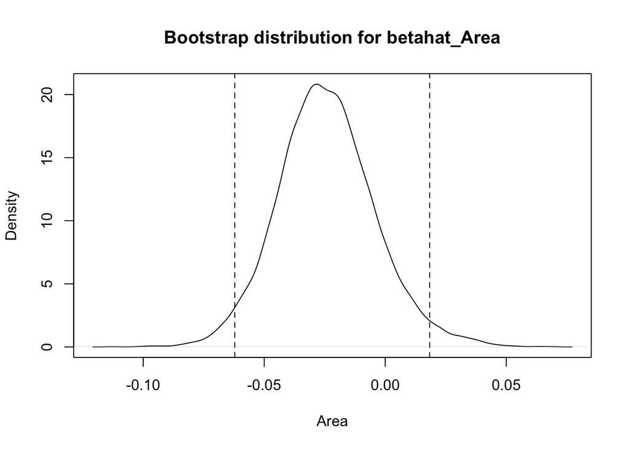

```r
plot(density(coefmat$Area), xlab = "Area", main = "") # plot density
title("Bootstrap distribution for betahat_Area") #title
abline(v = c(-0.06216773, 0.01836816), lty = 2) # plot CI
```

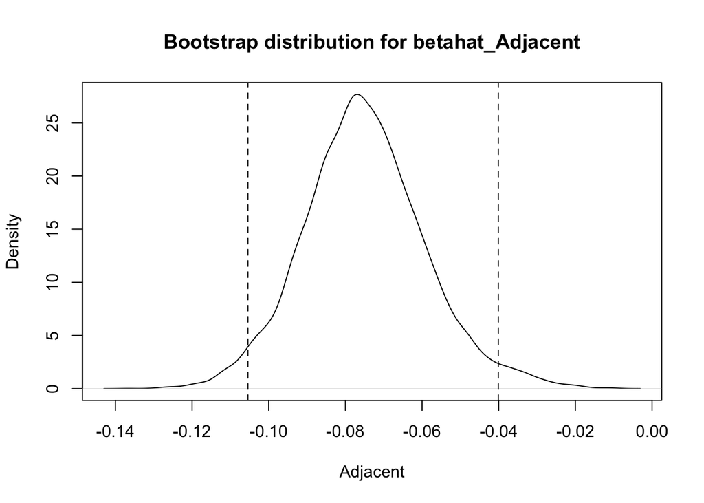

```r
# same thing for Adjacent
plot(density(coefmat$Adjacent), xlab = "Adjacent", main = "") # plot density
title("Bootstrap distribution for betahat_Adjacent") #title
abline(v = c(-0.10542995, -0.04009888), lty = 2) # plot CI
```

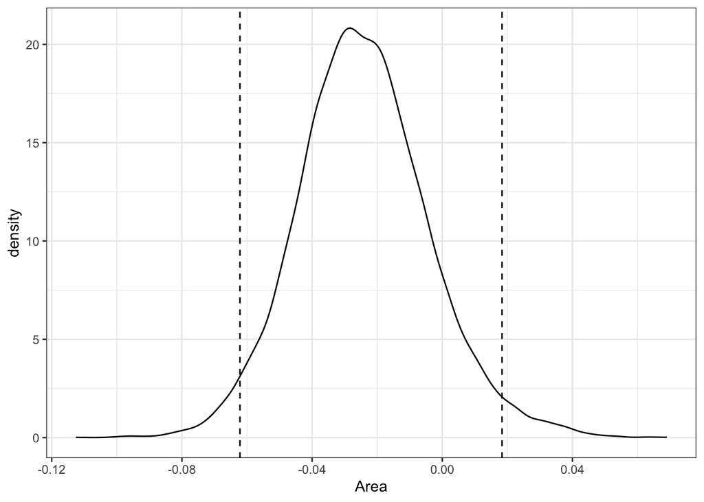

```r
#library(ggplot2) # same plots using ggplot2
ggplot(coefmat, aes(x = Area)) +
  geom_density() +
  geom_vline(xintercept = c(-0.06216773, 0.01836816), lty = 2) +
  theme_bw()
```

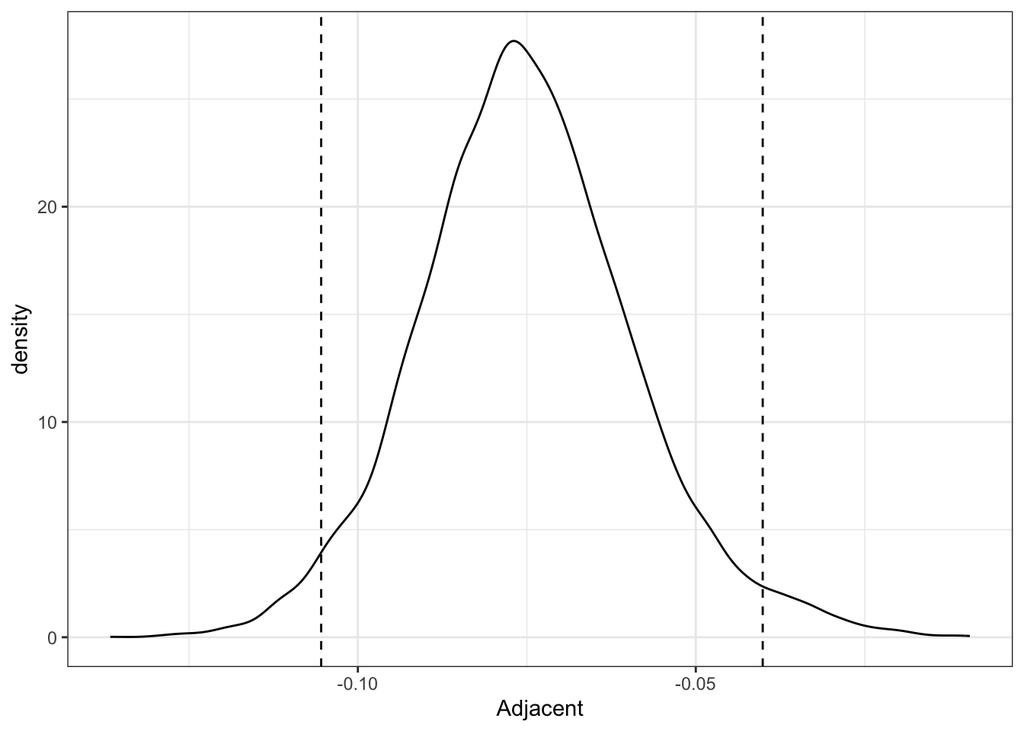

```r
ggplot(coefmat, aes(x = Adjacent)) +
  geom_density() +
  geom_vline(xintercept = c(-0.10542995, -0.04009888), lty = 2) +
  theme_bw()
```

- Both densities are roughly symmetric and normal, though this is not always the case.
- Bootstrap methods can be used for hypothesis testing, but permutation-based methods are generally preferred.
- There are other (more complex) methods for constructing bootstrap confidence intervals for the coefficients.

# Appendix A: Summary of Hypothesis Testing

1. State the **hypotheses** and identify (from the alternative claim in $H_a$) if it is a one or two-tailed test.
- $H_0$ is the “boring” claim. Express using an equal sign $=$.
- $H_a$ is the claim we want to show is likely true. Use inequality sign ($>$, $<$, or $\ne$).
- State both $H_0$ and $H_a$ in terms of population parameters such as $\mu$ and $p$.
2. Compute the **test statistic**.
- If the observed sample contradicts the null claim, the result is significant.
- A standardized test statistic measures how many SE’s the observed stat is from the null claim.
- A standardized test statistic with a large absolute value is supporting evidence to reject $H_0$.
3. Using the null distribution, compute the **p-value**. The p-value is the probability of getting a sample with a test statistic as or more extreme than the observed sample assuming $H_0$ is true.
- The p-value is the area in one or both tails beyond the test statistic.
- The p-value is a probability, so we have $0 < \mbox{p-value} < 1$.
- The smaller the p-value, the stronger the evidence to reject $H_0$.
4. Based on the **significance level**, $\alpha$, make a decision to reject or not reject the null hypothesis
- If p-value $\leq \alpha$, we reject $H_0$.
- If p-value $> \alpha$, we do not reject $H_0$.
5. **Summarize the results** in practical terms, **in the context of the example**.
- If we reject $H_0$, this means there is enough evidence to support the claim in $H_a$.
- If we do not reject $H_0$, this means there is not evidence to reject $H_0$ nor support $H_a$. The test is inconclusive.